# Ejercicio Cluster

Daniel Robins - Fernando Palacios

23 de mayo de 2018

### Dataset

El dataset utilizado corresponde a datos de ausentismo en el trabajo obtenido del siguiente sitio https://archive.ics.uci.edu/ml/datasets/Absenteeism+at+work

```r
ausentismo <- read.csv("https://raw.githubusercontent.com/fpalaciosdrobins/diplodatos/master/An-lisis%20Exploratorio%20y%20Curaci-n%20de%20Datos/Absenteeism_at_work.csv",header=TRUE,sep=";")

summary(ausentismo)
```

```
##        ID        Reason.for.absence Month.of.absence Day.of.the.week
##  Min.   : 1.00   Min.   : 0.00      Min.   : 0.000   Min.   :2.000
##  1st Qu.: 9.00   1st Qu.:13.00      1st Qu.: 3.000   1st Qu.:3.000
##  Median :18.00   Median :23.00      Median : 6.000   Median :4.000
##  Mean   :18.02   Mean   :19.22      Mean   : 6.324   Mean   :3.915
##  3rd Qu.:28.00   3rd Qu.:26.00      3rd Qu.: 9.000   3rd Qu.:5.000
##  Max.   :36.00   Max.   :28.00      Max.   :12.000   Max.   :6.000
##     Seasons      Transportation.expense Distance.from.Residence.to.Work
##  Min.   :1.000   Min.   :118.0          Min.   : 5.00
##  1st Qu.:2.000   1st Qu.:179.0          1st Qu.:16.00
##  Median :3.000   Median :225.0          Median :26.00
##  Mean   :2.545   Mean   :221.3          Mean   :29.63
##  3rd Qu.:4.000   3rd Qu.:260.0          3rd Qu.:50.00
##  Max.   :4.000   Max.   :388.0          Max.   :52.00
##   Service.time        Age        Work.load.Average.day   Hit.target
##  Min.   : 1.00   Min.   :27.00   Min.   :205.9         Min.   : 81.00
##  1st Qu.: 9.00   1st Qu.:31.00   1st Qu.:244.4         1st Qu.: 93.00
##  Median :13.00   Median :37.00   Median :264.2         Median : 95.00
##  Mean   :12.55   Mean   :36.45   Mean   :271.5         Mean   : 94.59
##  3rd Qu.:16.00   3rd Qu.:40.00   3rd Qu.:294.2         3rd Qu.: 97.00
##  Max.   :29.00   Max.   :58.00   Max.   :378.9         Max.   :100.00
##  Disciplinary.failure   Education          Son        Social.drinker
##  Min.   :0.00000      Min.   :1.000   Min.   :0.000   Min.   :0.0000
##  1st Qu.:0.00000      1st Qu.:1.000   1st Qu.:0.000   1st Qu.:0.0000
##  Median :0.00000      Median :1.000   Median :1.000   Median :1.0000
##  Mean   :0.05405      Mean   :1.292   Mean   :1.019   Mean   :0.5676
##  3rd Qu.:0.00000      3rd Qu.:1.000   3rd Qu.:2.000   3rd Qu.:1.0000
##  Max.   :1.00000      Max.   :4.000   Max.   :4.000   Max.   :1.0000
##  Social.smoker          Pet             Weight           Height
##  Min.   :0.00000   Min.   :0.0000   Min.   : 56.00   Min.   :163.0
##  1st Qu.:0.00000   1st Qu.:0.0000   1st Qu.: 69.00   1st Qu.:169.0
##  Median :0.00000   Median :0.0000   Median : 83.00   Median :170.0
##  Mean   :0.07297   Mean   :0.7459   Mean   : 79.04   Mean   :172.1
##  3rd Qu.:0.00000   3rd Qu.:1.0000   3rd Qu.: 89.00   3rd Qu.:172.0
##  Max.   :1.00000   Max.   :8.0000   Max.   :108.00   Max.   :196.0
##  Body.mass.index Absenteeism.time.in.hours
##  Min.   :19.00   Min.   :  0.000
##  1st Qu.:24.00   1st Qu.:  2.000
##  Median :25.00   Median :  3.000
##  Mean   :26.68   Mean   :  6.924
##  3rd Qu.:31.00   3rd Qu.:  8.000
##  Max.   :38.00   Max.   :120.000
```

### Análisis de Variables

Queremos analizar del set de datos y las variables que tenemos continuas son las siguientes:

Día de la semana, precio del transporte, distancia desde la casa al trabajo, tiempo de ausentismo en horas y cantidad de hijos

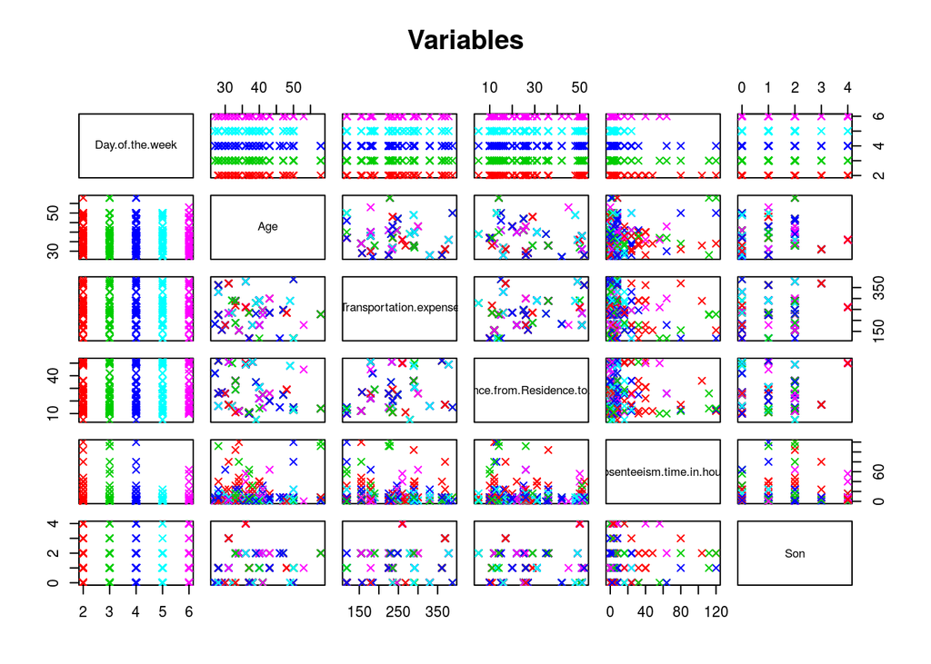

```r
#ausentismo$Day.of.the.week
#ausentismo$Age
#ausentismo$Transportation.expense
#ausentismo$Distance.from.Residence.to.Work
#ausentismo$Absenteeism.time.in.hours

analisis <- subset(ausentismo, select=c("Day.of.the.week","Age","Transportation.expense","Distance.from.Residence.to.Work","Absenteeism.time.in.hours","Son"))

variables_analizadas = 6

plot(analisis[,1:6], col = analisis$Day.of.the.week, pch = 4, main = "Variables")
```

# Aplicamos la función de normalización scale para las variables

```r
# Aplicamos la función de normalización scale para las variables

ausentismo.scale <- scale(analisis[,1:6])

set.seed(100)
ausentismo.km <- kmeans(ausentismo.scale,centers=6)

names(ausentismo.km)
```

```
## [1] "cluster"      "centers"      "totss"        "withinss"
## [5] "tot.withinss" "betweenss"    "size"         "iter"
## [9] "ifault"
```

```r
print("..........Cluster...........")
```

```
## [1] "..........Cluster..........."
```

```r
ausentismo.km$cluster
```

```
##   1   2   3   4   5   6   7   8   9  10  11  12  13  14  15  16  17  18
##   2   5   6   3   2   6   2   2   5   3   2   2   2   6   6   3   6   6
##  19  20  21  22  23  24  25  26  27  28  29  30  31  32  33  34  35  36
##   1   3   1   6   2   2   2   2   2   1   2   6   6   3   3   3   6   2
##  37  38  39  40  41  42  43  44  45  46  47  48  49  50  51  52  53  54
##   2   6   3   2   1   5   6   3   5   5   6   3   2   3   2   1   1   5
##  55  56  57  58  59  60  61  62  63  64  65  66  67  68  69  70  71  72
##   2   5   1   6   2   3   6   2   6   5   5   1   6   1   5   1   3   3
##  73  74  75  76  77  78  79  80  81  82  83  84  85  86  87  88  89  90
##   6   1   2   3   1   2   2   2   6   1   6   3   3   5   1   3   1   5
##  91  92  93  94  95  96  97  98  99 100 101 102 103 104 105 106 107 108
##   1   3   1   2   3   1   2   3   3   4   5   3   1   2   4   2   1   2
## 109 110 111 112 113 114 115 116 117 118 119 120 121 122 123 124 125 126
##   1   2   5   3   1   1   5   5   5   1   1   1   1   5   1   5   5   5
## 127 128 129 130 131 132 133 134 135 136 137 138 139 140 141 142 143 144
```

[output cut: 69 more lines]

```r
print("..........Centers...........")
```

```
## [1] "..........Centers..........."
```

```r
ausentismo.km$centers
```

```
##   Day.of.the.week        Age Transportation.expense
## 1     0.047615164 -1.1382432            -0.05042762
## 2     0.137423388 -0.5300776             1.28615916
## 3     0.079207755  0.9194015             0.46260552
## 4    -0.543026978  0.5148683            -0.36659000
## 5    -0.274517580  0.5694511            -1.36581699
## 6     0.008415711  0.1551659            -0.54553605
##   Distance.from.Residence.to.Work Absenteeism.time.in.hours         Son
## 1                      -0.3082164                -0.2010456 -0.44063727
## 2                       0.8591395                 0.0600169  1.42355383
## 3                      -0.4247153                -0.1006606  0.08281484
## 4                      -0.8368924                 6.0388762  0.37292363
## 5                      -1.1806010                -0.1191403 -0.14407352
## 6                       1.4386219                -0.2010669 -0.87575600
```

```r
print("..........totss.............")
```

```
## [1] "..........totss............."
```

```r
ausentismo.km$totss
```

```
## [1] 4434
```

```r
print("..........withinss..........")
```

```
## [1] "..........withinss.........."
```

```r
ausentismo.km$withinss
```

```
## [1] 331.2842 483.9045 507.5946 122.3459 335.6493 167.1495
```

```r
print("..........tot.withinss......")
```

```
## [1] "..........tot.withinss......"
```

```r
ausentismo.km$tot.withinss
```

```
## [1] 1947.928
```

```r
print("..........betweenss.........")
```

```
## [1] "..........betweenss........."
```

```r
ausentismo.km$betweenss
```

```
## [1] 2486.072
```

```r
print("..........size..............")
```

```
## [1] "..........size.............."
```

```r
ausentismo.km$size
```

```
## [1] 172 127 182  14 122 123
```

```r
print("..........iter..............")
```

```
## [1] "..........iter.............."
```

```r
ausentismo.km$iter
```

```
## [1] 4
```

# Determinar el número óptimo de Clusters por la suma de distancias interclusters

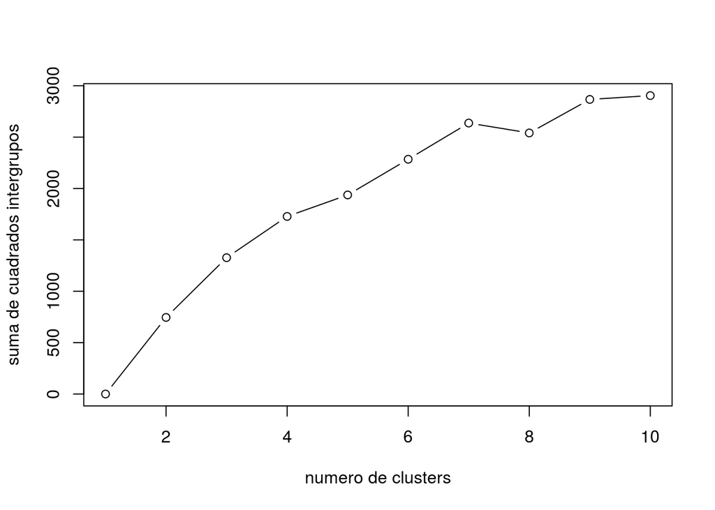

```r
# Determinar el número óptimo de Clusters

sumbt <- kmeans(ausentismo.scale,centers = 1)$betweens

for (i in 2:10) sumbt[i] <- kmeans(ausentismo.scale,centers = i)$betweenss

plot(1:10,sumbt,type="b",xlab="numero de clusters",ylab = "suma de cuadrados intergrupos")
```

# Análisis de Resultados

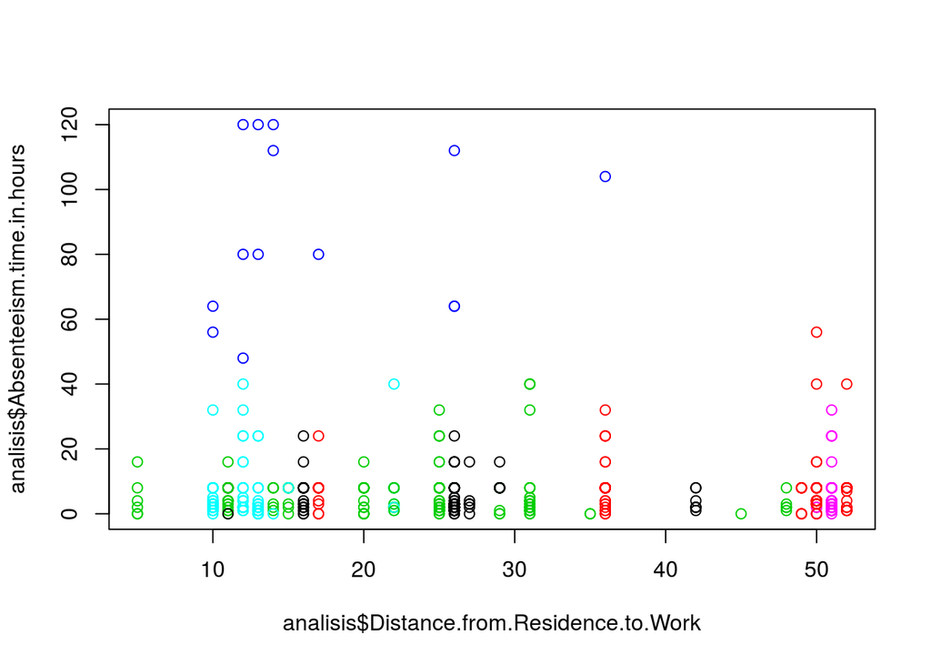

```r
# Inspeccionando los resultados

plot(analisis$Distance.from.Residence.to.Work,analisis$Absenteeism.time.in.hours,col=ausentismo.km$cluster)
```

```r
aggregate(analisis[,1:6], by=list(ausentismo.km$cluster),median)
```

```
##   Group.1 Day.of.the.week  Age Transportation.expense
## 1       1               4 28.0                    225
## 2       2               4 33.0                    289
## 3       3               4 41.0                    246
## 4       4               3 35.5                    167
## 5       5               3 37.0                    118
## 6       6               4 38.0                    179
##   Distance.from.Residence.to.Work Absenteeism.time.in.hours Son
## 1                            26.0                         3   0
## 2                            50.0                         8   2
## 3                            25.0                         3   1
## 4                            13.5                        80   2
## 5                            12.0                         3   1
## 6                            51.0                         3   0
```